# Evaluacion 1 R

Graciela Bravo

26 de agosto de 2018

## Reporte

Es este documento se utilizo una base de datos de biodiversidad de los parques nacionales encontrados en Norte America, especaficamente en aquellos en EE.UU. A continuacion mostramos la ubicacion de estos parques en el siguiente mapa.

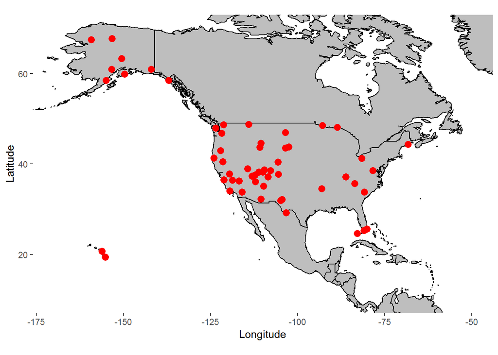

Figura 1. Localizacion de los parques nacionales de EE.UU analizados.

Sorpresivamente encontramos que dos parques nacionales se encuentran en el estado de Hawaii a pesar de ser una zona muy pequeña (28.311 km²), el *Haleakala National Park* y el *Hawaii Volcanoes National Park*.

Al analizar la cantidad de especies encontradas por categoria para estos dos parques, se realizo una tabla con la distribucion de las especies como se muestra a continuacion.

Tabla 1. Distribucion de las categorias de las especies segun los parques

| Category | Haleakala National Park | Hawaii Volcanoes National Park |
| --- | --- | --- |
| Algae | NA | NA |
| Amphibian | 3 | 4 |
| Bird | 44 | 78 |
| Crab/Lobster/Shrimp | 18 | 56 |
| Fish | 6 | 4 |
| Fungi | 66 | 7 |
| Insect | 1061 | 1429 |
| Invertebrate | 37 | 173 |
| Mammal | 15 | 15 |
| Nonvascular Plant | 227 | 135 |
| Reptile | 10 | 13 |
| Slug/Snail | 47 | 71 |
| Spider/Scorpion | 46 | 101 |
| Vascular Plant | 1000 | 1212 |

Lo mismo representado en la Tabla 1 se puede ver de mejor manera representado en el Grafico 1. Como puede observarse la mayor cantidad de especies encontradas para *Haleakala National Park* y *Hawaii Volcanoes National Park* son tanto las especies de plantas vasculares y los insectos.

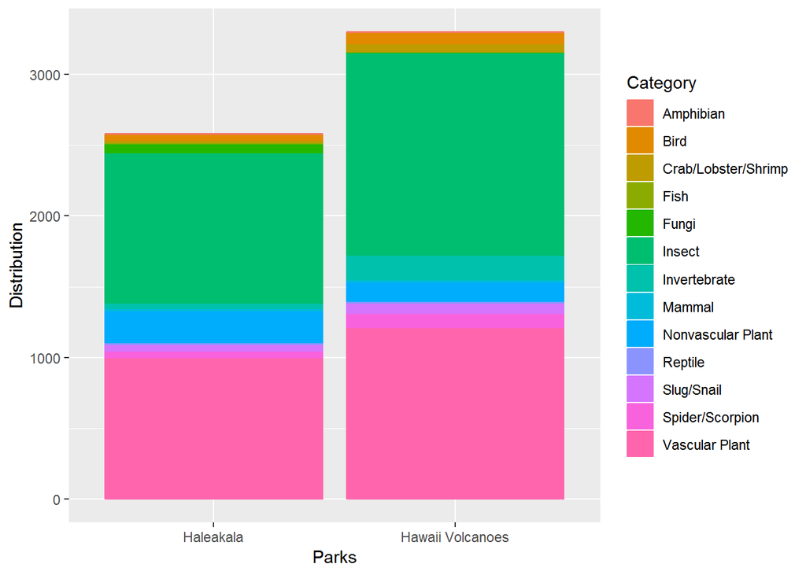

Grafico 1. Distribucion de las especies encontradas en los parques nacionales en Hawaii

Si observamos las especies de **Plantas Vasculares** para ambos parques se aprecian especies que no son nativas de la localidad.

Tabla 2. Plantas Vasculares Nativas y No Nativas

| Park | Nativeness | Number of Species |
| --- | --- | --- |
| Haleakala National Park | Native | 469 |
| Haleakala National Park | Not Native | 497 |
| Hawaii Volcanoes National Park | Native | 421 |
| Hawaii Volcanoes National Park | Not Native | 791 |

Para saber como se clasifican en abundancia las especies nativas y no nativas, se realizó una selección de las especies y su respectiva clasificación como abundante, comun, ocasional, raro y No comun (Figura 2). Como puede verse, la mayoria de las especies Nativas y No Nativas se distribuyen en su mayoria en la clasificacion Raro y No Comun.

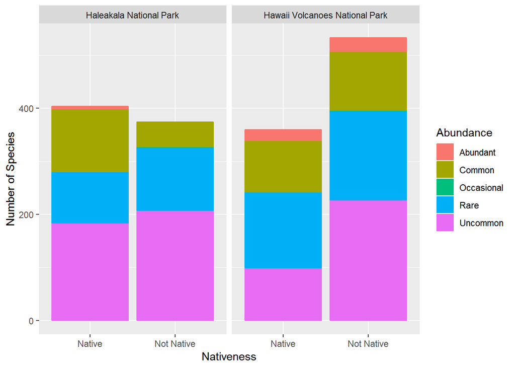

Figura 2. Abundancia de Especies Nativas y Especies No Nativas

Esto es debido a que la mayoria de las especies que tienen estos dos parques son de especies exclusivas y dificiles de encontrar en otras localidades.